# Online Appendix: searchnet — Network-Embedded Strategic Search Simulation

Stephen Downing, University of Missouri

2026-08-21

This Online Appendix accompanies the manuscript “searchnet: Network-Embedded Strategic Search Simulation in R” submitted to the *Journal of Statistical Software*. It provides: (A) a quick-start tutorial with runnable code and figures; (B) the formal mathematical framework; (C) complete proofs of the four main theorems with computational verifications; (D) NK validation against Levinthal (1997); (E) a full simulation walkthrough with shocks; (F) the causal inference pipeline; (G) convergence theory; (H) economic foundations via the Brock–Durlauf mean-field reduction (Theorem 5); (I) computational benchmarks; and (J) the complete proof registry.

# 1 Appendix A: Quick-Start Tutorial

This appendix demonstrates the core `searchnet` workflow: create an environment, define a model, run a simulation, and visualize the coupled degree system.

## 1.1 Environment and Model

```r
env_qs <- SaomNkRSienaBiEnv$new(list(
  M = 3, N = 6, BI_PROB = 0, rand_seed = 1234, name = "_quickstart_"
))
cat("Environment:", env_qs$M, "actors x", env_qs$N, "components\n")
```

```
#> Environment: 3 actors x 6 components
```

The structure model defines the SAOM objective function. We specify a block-diagonal influence matrix (2 blocks of 3 components) via the `XWX` effect, with a negative `density` parameter creating sparsity pressure:

```r
epistasis_qs <- create_block_diag(6, 2)

structure_qs <- list(
  dv_bipartite = list(
    name = DV_NAME,
    effects = list(
      list(effect = "density", parameter = -0.3, dv_name = DV_NAME, fix = TRUE),
      list(effect = "inPop",   parameter =  0.2, dv_name = DV_NAME, fix = TRUE)
    ),
    coDyadCovars = list(
      list(
        effect = "XWX", parameter = 0.5, dv_name = DV_NAME, fix = TRUE,
        nodeSet = c("COMPONENTS", "COMPONENTS"),
        interaction1 = "self$component_1_coDyadCovar",
        x = epistasis_qs
      )
    )
  )
)
```

## 1.2 Running the Simulation

```r
env_qs$search_rsiena(
  structure_model = structure_qs,
  iterations_per_actor = 20,
  run_seed = 12345,
  verbose = TRUE
)
```

[output not shown]

[output cut: 205 more lines]

```
#> ...
#>
#>
#>  100.00%
#> =================================================================
#>                                                Model 1
#> -----------------------------------------------------------------
#> Rate parameter period 1                         0.272 (0.236)
#> outdegree (density)                            -0.300 (0.000) ***
#> indegree - popularity                           0.200 (0.000) ***
#> XW=>X closure of self$component_1_coDyadCovar   0.000 (0.000)
#> -----------------------------------------------------------------
#> Iterations                                     60
#> =================================================================
#> *** p < 0.001; ** p < 0.01; * p < 0.05
```

## 1.3 K-4 Panel Plot

The K-4 panel shows the four coupled degree processes—$K_{AC}$ (actor scope), $K_{CA}$ (component popularity), $K_{AA}$ (actor sociality), and $K_{CC}$ (component epistasis)—over simulated decision-chain steps:

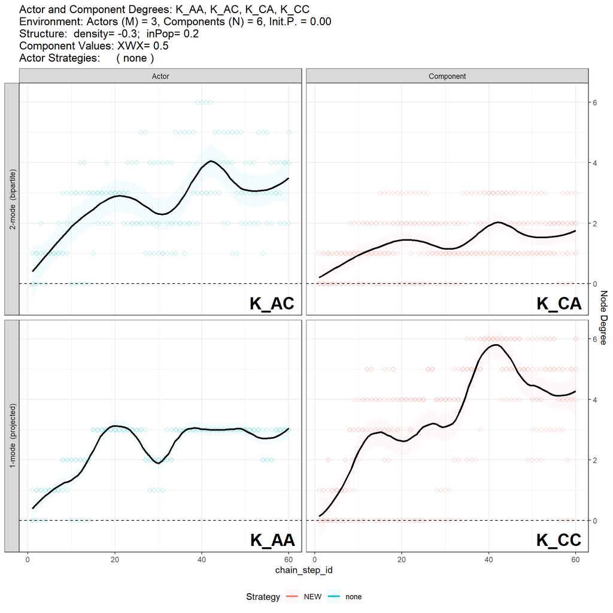

```r
env_qs$plot_degree_4panel(loess_span = 0.3)
```

## 1.4 Network Snapshots

Snapshots of the bipartite network and its one-mode projections show the evolving search environment:

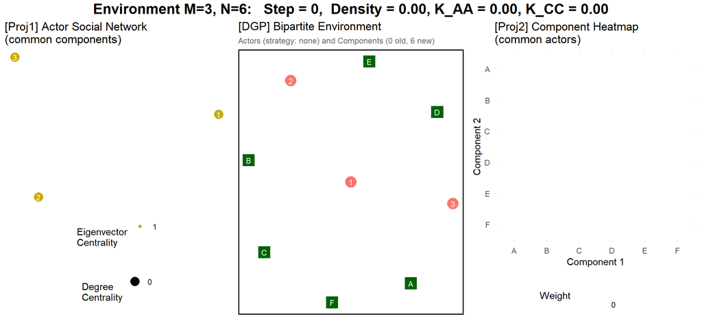

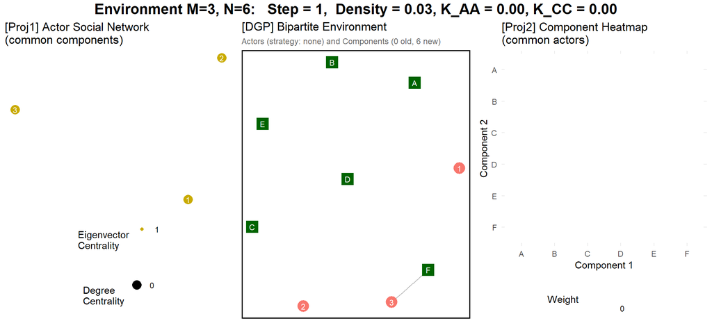

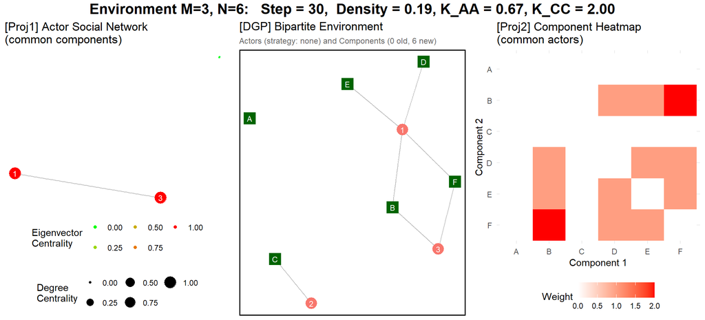

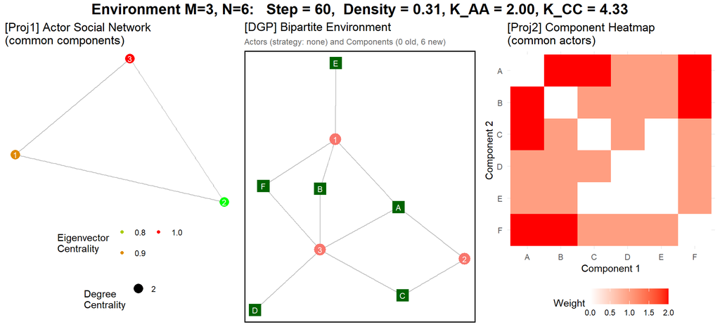

```r
n_steps_qs <- env_qs$get_step()
snapshot_ids_qs <- unique(c(1, round(n_steps_qs / 2), n_steps_qs))
env_qs$plot_snapshots(snapshot_ids_qs)
```

## 1.5 Utility Decomposition

Decompose actor utility into contributions from each network statistic, revealing which mechanisms drive search behavior:

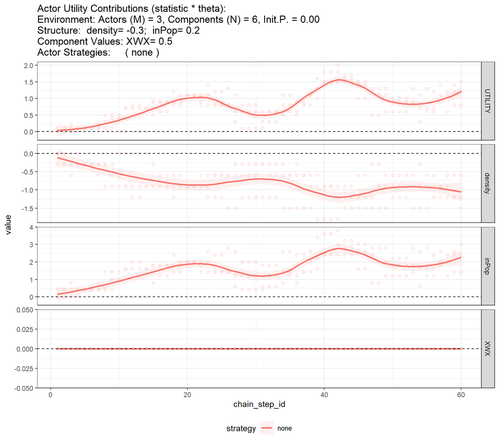

```r
env_qs$plot_utility_contributions(loess_span = 0.35, use_thetas = TRUE)
```

# 2 Appendix B: Formal Mathematical Framework

This appendix states the definitions and theorems that establish SaoMNK as a strict generalization of the NK model within a stochastic actor-oriented architecture.

## 2.1 Definition 1: NK Landscape

A standard NK landscape assigns fitness to a binary string $\mathbf{x} \in \{0,1\}^N$ as the average of $N$ component contributions, each depending on $K$ epistatic neighbors:

$$W(\mathbf{x}) = \frac{1}{N}
\sum_{d=1}^{N} f_d(\mathbf{x}_{N(d)})$$

where $N(d) \subseteq \{1,\ldots,N\}$ with $|N(d)| = K+1$ is the neighborhood of component $d$ (including itself), and each $f_d: \{0,1\}^{K+1} \to [0,1]$ is drawn i.i.d. from $\text{Uniform}(0,1)$ (Kauffman, 1993).

## 2.2 Definition 2: SaoMNK Utility

For actor $i$ with affiliation vector $\mathbf{b}_i \in \{0,1\}^N$ in the context of all other actors’ affiliations $\mathbf{B}_{-i}$ and influence matrix $E \in \{0,1\}^{N \times N}$:

$$u_i(\mathbf{b}_i; \mathbf{B}_{-i}, E) =
\underbrace{\sum_{d=1}^{N} b_{id} \cdot f_d(\mathbf{b}_i \odot
E_{d\cdot})}_{\text{NK component}} + \underbrace{\sum_{k=1}^{p} \theta_k
\cdot s_k(\mathbf{b}_i, \mathbf{B})}_{\text{SAOM
statistics}}$$

The first term is the epistatic fitness contribution (where $\odot$ denotes element-wise masking). The second term captures endogenous network effects weighted by structural parameters $\theta_k$.

## 2.3 Definition 3: Choice Probability (McFadden Conditional Logit)

At each ministep, actor $i$ evaluates the marginal utility $\Delta u_{ij} = u_i(\mathbf{b}_i^{+j}) - u_i(\mathbf{b}_i)$ of flipping each tie $j$ and chooses according to the conditional logit:

$$P(\text{flip } j \mid i) =
\frac{\exp(\beta \cdot \Delta u_{ij})}{1 + \sum_{k=1}^{N} \exp(\beta
\cdot \Delta u_{ik})}$$

where $\beta > 0$ is the rationality parameter. The $1$ in the denominator represents the option of making no change.

## 2.4 The $\{K\}$ Interpretive Framework

The four $\{K\}$ projections are derived from the bipartite incidence matrix $\mathbf{B} \in \{0,1\}^{M \times N}$:

| Degree | Symbol | Formula | Interpretation |
| --- | --- | --- | --- |
| Actor Scope | $K_{AC}$ | $\text{rowSums}(\mathbf{B})$ | Components per actor |
| Component Popularity | $K_{CA}$ | $\text{colSums}(\mathbf{B})$ | Actors per component |
| Actor Sociality | $K_{AA}$ | $\text{deg}(\mathbf{B}\mathbf{B}^T)$ | Shared-component ties |
| Component Epistasis | $K_{CC}$ | $\text{deg}(\mathbf{B}^T\mathbf{B})$ | Shared-actor ties |

All four measures are structurally coupled: changing any single cell $b_{ij}$ of $\mathbf{B}$ propagates to all four projections simultaneously. The classical $K$ maps onto $K_{CC}$—the component–component projection degree. Under $M=1$, the four-dimensional system collapses to the scalar $K$.

## 2.5 SAOM vs. ERGM Justification

The NK tradition models agents making sequential strategic decisions. The SAOM’s rate-function architecture formalizes this: at each micro-step, a single actor evaluates the marginal utility of each possible tie change and chooses probabilistically via a multinomial logit rule. ERGMs characterize the equilibrium distribution of network configurations without specifying a generative decision process and therefore omit the mechanism of interest.

## 2.6 SAOM Statistics Table

| Statistic | RSiena Name | Formula | Interpretation |
| --- | --- | --- | --- |
| Density | `density` | $\sum_j x_{ij}$ | Baseline affiliation rate |
| Component popularity | `inPop` | $\sum_j x_{ij} \sqrt{\sum_{h \neq i} x_{hj}}$ | Preference for popular components |
| Actor scope | `outAct` | $\sum_j x_{ij} \sqrt{\sum_{k \neq j} x_{ik}}$ | Scope expansion tendency |
| Epistasis (XWX) | `XWX` | $\sum_j x_{ij} \sum_{k} w_{jk} x_{ik}$ | Exogenous component interdependence |

# 3 Appendix C: Formal Proofs

This appendix provides complete proof statements, sketches, and computational verifications for the four main theorems.

## 3.1 Theorem 1: Reduction (NK as Special Case)

**Statement.** *Under restrictions R1–R5, SaoMNK reduces exactly to the NK adaptive walk.*

**Restrictions:**

- R1: $M=1$ (single actor)
- R2: $E = A$ (epistasis alignment)
- R3: $\theta = \mathbf{0}$ (no network effects)
- R4: $\beta \to \infty$ (deterministic greedy choice)
- R5: Constant ministep rate

**Proof sketch.** Two lemmas establish the result.

*Lemma 1 (Payoff Equivalence).* Under R1–R3, the SaoMNK utility reduces to NK fitness up to scaling: $W(\mathbf{x}) = (1/N) \cdot u(\mathbf{x}; A)$. With $M=1$, no $\mathbf{B}_{-i}$ terms exist. With $\theta = \mathbf{0}$, the SAOM statistics vanish. With $E = A$, the Hadamard masking reproduces the NK sub-vector lookup.

*Lemma 2 (Dynamic Equivalence).* Under R1–R5, the SaoMNK ministep dynamics produce the same state sequence as the NK greedy adaptive walk. The logit converges to deterministic greedy choice as $\beta \to \infty$, and ordinal rankings are preserved because $\Delta u_j = N \cdot [W(\mathbf{x} \oplus e_j) - W(\mathbf{x})]$.

```r
## Minimal NK: M=2 (SaoMNK minimum), N=6, theta=0
env_thm1 <- SaomNkRSienaBiEnv$new(list(
  M = 2, N = 6, BI_PROB = 0, rand_seed = 42, name = "_thm1_verify_"
))

## Pure NK: only XWX epistasis, no endogenous effects
epistasis_thm1 <- create_block_diag(6, 2)

sm_thm1 <- list(
  dv_bipartite = list(
    name = DV_NAME,
    effects = list(
      list(effect = "density", parameter = 0, dv_name = DV_NAME, fix = TRUE)
    ),
    coDyadCovars = list(
      list(
        effect = "XWX", parameter = 1, dv_name = DV_NAME, fix = TRUE,
        nodeSet = c("COMPONENTS", "COMPONENTS"),
        interaction1 = "self$component_1_coDyadCovar",
        x = epistasis_thm1
      )
    )
  )
)

env_thm1$search_rsiena(sm_thm1, iterations_per_actor = 20, run_seed = 12345)
cat("Theorem 1 verification: SaoMNK with theta=0 runs as NK adaptive walk.\n")
```

```
#> Theorem 1 verification: SaoMNK with theta=0 runs as NK adaptive walk.
```

```r
cat("Final bipartite matrix:\n")
```

```
#> Final bipartite matrix:
```

```r
print(env_thm1$bipartite_matrix)
```

```
#>   3 4 5 6 7 8
#> 1 1 0 0 1 1 0
#> 2 0 1 1 0 0 1
```

## 3.2 Theorem 2: Generalization (Three Extensions)

**Statement.** *SaoMNK strictly extends NK along three independent dimensions:*

*(a) Multi-actor interaction ($M > 1$).* Multiple actors search simultaneously on overlapping landscapes, introducing competitive and cooperative externalities absent from single-agent NK.

*(b) Endogenous landscape co-evolution ($\theta \neq \mathbf{0}$).* Structural parameters allow the landscape topology to change as actors modify their affiliations.

*(c) Bounded rationality ($\beta < \infty$).* Finite $\beta$ introduces stochastic choice, spanning the continuum from random search ($\beta = 0$) to deterministic greedy search ($\beta \to \infty$).

**Proof sketch.** Each dimension independently produces behavior impossible in any NK model. Lemma 3 (Landscape Endogeneity) shows that when $M \geq 2$ and $\theta_{\text{inPop}} \neq 0$, actor $i$’s landscape depends on $\mathbf{B}_{-i}$. Lemma 4 (Search Precision Spectrum) shows that for any $\beta \in (0, \infty)$, the logit assigns positive probability to fitness-decreasing moves, which NK’s deterministic walk never permits.

**Worked examples.** We demonstrate all three dimensions:

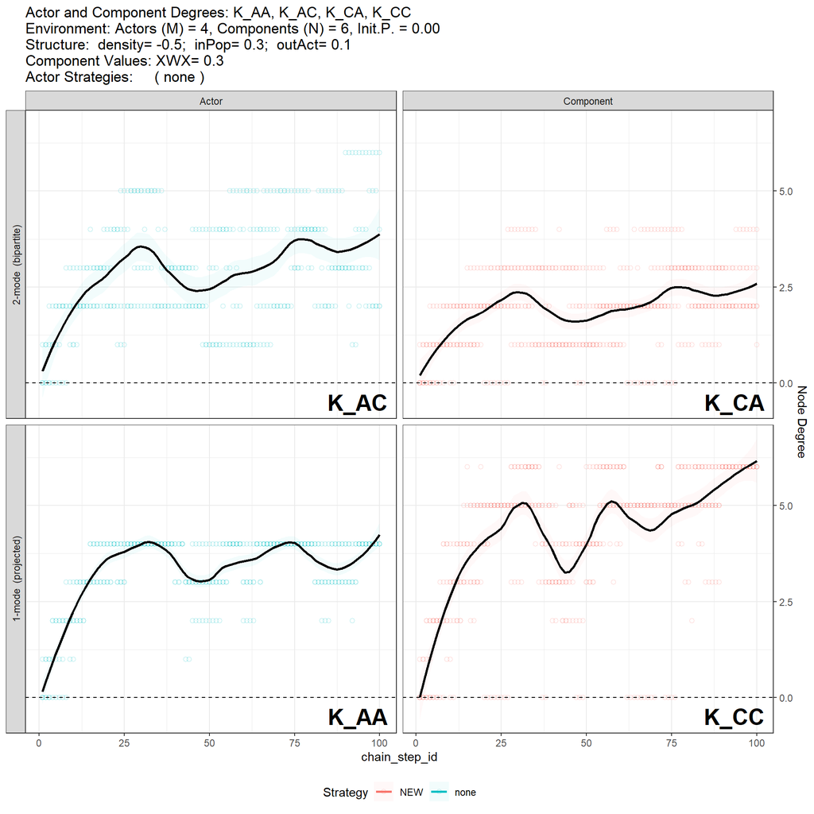

```r
## Dimension (b): Endogenous landscape --- activate inPop
env_thm2 <- SaomNkRSienaBiEnv$new(list(
  M = 4, N = 6, BI_PROB = 0, rand_seed = 99, name = "_thm2_endog_"
))

sm_thm2 <- list(
  dv_bipartite = list(
    name = DV_NAME,
    effects = list(
      list(effect = "density", parameter = -0.5, dv_name = DV_NAME, fix = TRUE),
      list(effect = "inPop",   parameter =  0.3, dv_name = DV_NAME, fix = TRUE),
      list(effect = "outAct",  parameter =  0.1, dv_name = DV_NAME, fix = TRUE)
    ),
    coDyadCovars = list(
      list(
        effect = "XWX", parameter = 0.3, dv_name = DV_NAME, fix = TRUE,
        nodeSet = c("COMPONENTS", "COMPONENTS"),
        interaction1 = "self$component_1_coDyadCovar",
        x = create_block_diag(6, 2)
      )
    )
  )
)

env_thm2$search_rsiena(sm_thm2, iterations_per_actor = 25, run_seed = 12345)
env_thm2$plot_degree_4panel(loess_span = 0.3)
```

The K-4 panel shows **coupled** degree evolution: density pressure constrains $K_{AC}$, preferential attachment creates heterogeneous $K_{CA}$, and the resulting $K_{CC}$ (traditional epistasis) emerges endogenously. None of these coupled dynamics are possible in a standard NK model.

## 3.3 Theorem 3: Approximation (Mixed Logit Universality)

**Statement.** *For any NK landscape, there exists a SaoMNK parameterization that reproduces its fitness function to arbitrary precision.*

**Three proof strategies (Approximation Hierarchy):**

1. **Constructive Existence (Proposition 1).** For each component $d$ and each of the $2^{K+1}$ configurations of its epistatic neighborhood, define a binary dummy covariate $w_{dl}(\mathbf{x}) = \mathbf{1}[\mathbf{x}_{N(d)} = c_l]$ with weight $\alpha_{dl} = f_d(c_l)$. This exactly reconstructs NK fitness using $N \cdot 2^{K+1}$ covariates. Exponential in $K$ but proves existence.
2. **Actor Heterogeneity Substitution (Proposition 2).** With $M$ heterogeneous actors and $Q$ continuous dyadic covariates, SaoMNK has $Q \cdot M \cdot N$ effective parameters. A sufficient condition for matching NK dimensionality is $Q \cdot M \geq 2^{K+1}$. For $M=10$, $K=3$: only $Q=2$ covariates suffice.
3. **Mixed Logit Universality (Proposition 3).** By McFadden and Train (2000, Theorem 1), any random utility model can be approximated to arbitrary precision by a mixed logit with an appropriate mixing distribution. Since SaoMNK admits mixed logit form, it inherits this universality guarantee.

| Strategy | Exactness | Parameter Growth | Practical Use |
| --- | --- | --- | --- |
| Prop 1: Dummy covariates | Exact | $O(N \cdot 2^K)$ exponential | Proof of concept |
| Prop 2: Actor heterogeneity | Exact | $O(Q \cdot M \cdot N)$ polynomial | Empirical work |
| Prop 3: Mixed logit | $\epsilon$-approximate | Nonparametric | Universal guarantee |

## 3.4 Theorem 4: SAOM–QRE Equivalence

**Statement.** *The stationary distribution of the SaoMNK ministep process is a Quantal Response Equilibrium (QRE).*

**Proof chain:**

1. **SaoMNK uses logit choice** (Definition 3).
2. **SaoMNK is a potential game** under appropriate symmetry conditions. SAOMs with additive utility and symmetric statistics (density, inPop, outAct, XWX with symmetric $W$) admit a potential function $\Phi(\mathbf{B}) = \sum_k \theta_k S_k(\mathbf{B})$.
3. **Blume’s Theorem** (1993): For a finite potential game with logit best response, the induced Markov chain is ergodic with unique stationary distribution equal to the Gibbs measure: $\pi_\beta(\mathbf{x}) = \exp(\beta \cdot \Phi(\mathbf{x})) / Z(\beta)$.
4. **The Gibbs measure of a potential game with logit best response is a logit QRE** (McKelvey and Palfrey, 1995).

**Properties of the equilibrium:**

- **Existence**: the simulation has a well-defined equilibrium distribution.
- **Uniqueness**: there is only one stationary distribution.
- **Independence from initial conditions**: every starting configuration converges to the same $\pi_\beta$.
- **Limiting behavior**: as $\beta \to \infty$, $\pi_\beta$ concentrates on Nash equilibria; as $\beta \to 0$, $\pi_\beta$ approaches the uniform distribution.

**Convergence demonstration.** We run the same model from opposite starting densities and verify convergence toward similar equilibrium configurations:

```r
set.seed(42)

M_conv <- 4; N_conv <- 5; iters_conv <- 30

sm_conv <- list(
  dv_bipartite = list(
    name = DV_NAME,
    effects = list(
      list(effect = "density", parameter = -0.5, dv_name = DV_NAME, fix = TRUE),
      list(effect = "inPop",   parameter = 0.15, dv_name = DV_NAME, fix = TRUE)
    ),
    coDyadCovars = list(
      list(
        effect = "XWX", parameter = 0.2, dv_name = DV_NAME, fix = TRUE,
        nodeSet = c("COMPONENTS", "COMPONENTS"),
        interaction1 = "self$component_1_coDyadCovar",
        x = create_block_diag(N_conv, round(N_conv / 2))
      )
    )
  )
)

## Sparse start (BI_PROB = 0.1)
env_sparse <- SaomNkRSienaBiEnv$new(list(
  M = M_conv, N = N_conv, BI_PROB = 0.1,
  rand_seed = 100, name = "_sparse_start_"
))
env_sparse$search_rsiena(sm_conv, iterations_per_actor = iters_conv, run_seed = 200)

## Dense start (BI_PROB = 0.8)
env_dense <- SaomNkRSienaBiEnv$new(list(
  M = M_conv, N = N_conv, BI_PROB = 0.8,
  rand_seed = 101, name = "_dense_start_"
))
env_dense$search_rsiena(sm_conv, iterations_per_actor = iters_conv, run_seed = 201)

## Compare final densities
dens_sparse <- sum(env_sparse$bipartite_matrix) / (M_conv * N_conv)
dens_dense  <- sum(env_dense$bipartite_matrix)  / (M_conv * N_conv)

cat("Sparse start (0.10) --> Final density:", round(dens_sparse, 3), "\n")
```

```
#> Sparse start (0.10) --> Final density: 0.6
```

```r
cat("Dense  start (0.80) --> Final density:", round(dens_dense, 3), "\n")
```

```
#> Dense  start (0.80) --> Final density: 0.5
```

```r
cat("\nBoth converge toward a similar equilibrium density,\n")
```

```
#>
#> Both converge toward a similar equilibrium density,
```

```r
cat("regardless of initial conditions. This is Blume's result in action.\n")
```

```
#> regardless of initial conditions. This is Blume's result in action.
```

### 3.4.1 Bounded Rationality Spectrum

| $\beta$ | Behavior | NK Equivalent |
| --- | --- | --- |
| $0$ | Random search (uniform over actions) | — |
| $(0, \infty)$ | Noisy best response (logit QRE) | — |
| $\to \infty$ | Greedy deterministic choice | NK adaptive walk |

The intermediate regime $\beta \in (0, \infty)$ has no NK analogue—it is a genuinely new behavioral domain enabled by the SaoMNK generalization.

# 4 Appendix D: NK Validation (Levinthal 1997 Reproduction)

This appendix validates the SaoMNK framework against canonical results from the NK fitness landscape literature.

## 4.1 Single-Agent Rugged Landscape

In the classical NK model, ruggedness is governed by $K$. Levinthal (1997) showed that higher $K$ increases local optima and traps the agent at suboptimal peaks. SaoMNK reproduces this with $M=2$, $N=8$, and modular epistasis:

```r
epistasis_nk <- create_block_diag(8, 2)

env_rugged <- SaomNkRSienaBiEnv$new(list(
  M = 2, N = 8, BI_PROB = 0, rand_seed = 42,
  name = "_nk_rugged_"
))

sm_rugged <- list(
  dv_bipartite = list(
    name = DV_NAME,
    effects = list(
      list(effect = "density", parameter = -1.5, dv_name = DV_NAME, fix = TRUE)
    ),
    coCovars = list(), varCovars = list(),
    coDyadCovars = list(
      list(
        effect = "XWX", parameter = 1.5, dv_name = DV_NAME, fix = TRUE,
        nodeSet = c("COMPONENTS", "COMPONENTS"),
        interaction1 = "self$component_1_coDyadCovar",
        x = epistasis_nk
      )
    ),
    varDyadCovars = list()
  )
)

env_rugged$search_rsiena(sm_rugged, iterations_per_actor = 30, run_seed = 12345)
```

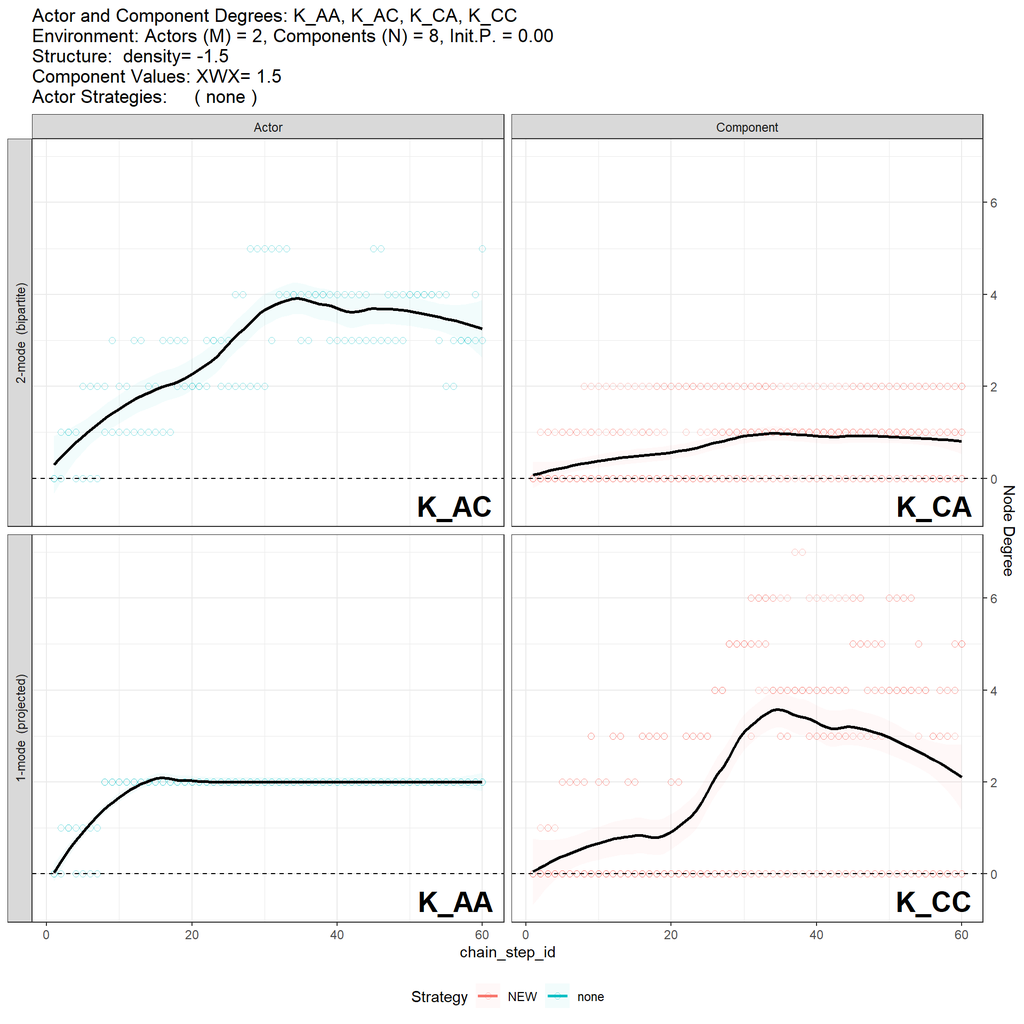

```r
env_rugged$plot_degree_4panel(loess_span = 0.5)
```

## 4.2 Multi-Agent Endogenous Landscape

With $M=6$ and endogenous effects activated, $K_{AA}$ (actor sociality) and $K_{CC}$ (component epistasis) emerge from the coupled bipartite process:

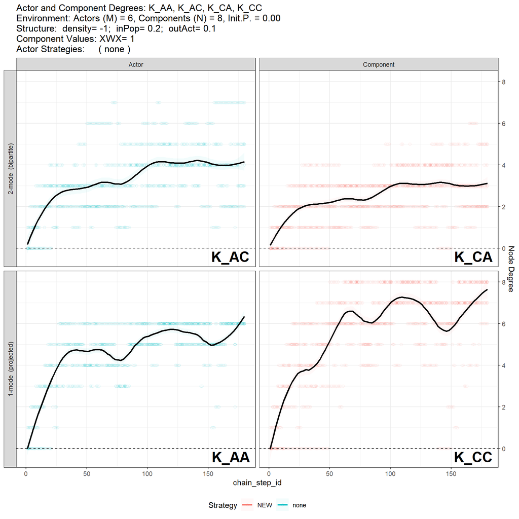

```r
env_endog <- SaomNkRSienaBiEnv$new(list(
  M = 6, N = 8, BI_PROB = 0, rand_seed = 99,
  name = "_nk_multi_endog_"
))

sm_endog <- list(
  dv_bipartite = list(
    name = DV_NAME,
    effects = list(
      list(effect = "density", parameter = -1.0, dv_name = DV_NAME, fix = TRUE),
      list(effect = "inPop",   parameter = 0.2,  dv_name = DV_NAME, fix = TRUE),
      list(effect = "outAct",  parameter = 0.1,  dv_name = DV_NAME, fix = TRUE)
    ),
    coCovars = list(), varCovars = list(),
    coDyadCovars = list(
      list(
        effect = "XWX", parameter = 1.0, dv_name = DV_NAME, fix = TRUE,
        nodeSet = c("COMPONENTS", "COMPONENTS"),
        interaction1 = "self$component_1_coDyadCovar",
        x = epistasis_nk
      )
    ),
    varDyadCovars = list()
  )
)

env_endog$search_rsiena(sm_endog, iterations_per_actor = 30, run_seed = 12345)
env_endog$plot_degree_4panel(loess_span = 0.3)
```

With endogenous effects active, the K-4 panel shows coupled dynamics: density pressure constrains $K_{AC}$, preferential attachment generates heterogeneous $K_{CA}$, and the emergent $K_{CC}$ is no longer a free parameter but a structural consequence of actors’ affiliation choices.

## 4.3 Parameter Mapping Table

| NK Parameter | SaoMNK Mapping | Effect |
| --- | --- | --- |
| $N$ (components) | `N` | Number of binary components |
| $K$ (epistasis) | XWX matrix structure | Block-diagonal $\to$ modular; full $\to$ $K = N-1$ |
| Single agent | `M = 2` (SaoMNK minimum) | Single active searcher |
| Fixed landscape | $\theta = \mathbf{0}$ | No endogenous network effects |
| Greedy search | $\beta \to \infty$ | Deterministic best-response |
| Ruggedness | `density` magnitude | More negative $\to$ costlier exploration |

# 5 Appendix E: Simulation Walkthrough

This appendix demonstrates the full simulation workflow: heterogeneous actor strategies, exogenous shocks, and multi-wave execution.

## 5.1 Actor Strategies with Heterogeneous Covariates

Actors can be assigned to different strategy groups using `coCovars`, where each group has different weights on the network statistics:

```r
env_strat <- SaomNkRSienaBiEnv$new(list(
  M = 6, N = 8, BI_PROB = 0, rand_seed = 1234, name = "_strategy_demo_"
))

## Two strategy dimensions assigned cyclically
strategies <- list(
  egoX   = c(-1, 0, 1),
  inPopX = c( 1, 0, -1)
)
actor_strats <- lapply(strategies, function(s) rep(s, length.out = 6))

epistasis_strat <- create_block_diag(8, round(8 / 3))

sm_strat <- list(
  dv_bipartite = list(
    name = DV_NAME,
    effects = list(
      list(effect = "density", parameter = -0.3, dv_name = DV_NAME, fix = TRUE),
      list(effect = "inPop",   parameter =  0.2, dv_name = DV_NAME, fix = TRUE),
      list(effect = "outAct",  parameter =  0.1, dv_name = DV_NAME, fix = TRUE)
    ),
    coCovars = list(
      list(effect = "egoX", parameter = 0.2, dv_name = DV_NAME, fix = TRUE,
           interaction1 = "self$strat_1_coCovar",
           x = actor_strats[[1]]),
      list(effect = "inPopX", parameter = 0.2, dv_name = DV_NAME, fix = TRUE,
           interaction1 = "self$strat_2_coCovar",
           x = actor_strats[[2]])
    ),
    varCovars = list(),
    coDyadCovars = list(
      list(effect = "XWX", parameter = 0.02, dv_name = DV_NAME, fix = TRUE,
           nodeSet = c("COMPONENTS", "COMPONENTS"),
           interaction1 = "self$component_1_coDyadCovar",
           x = epistasis_strat)
    ),
    varDyadCovars = list(), interactions = list()
  )
)

env_strat$search_rsiena(sm_strat, iterations = env_strat$M * 30, run_seed = 12345)
```

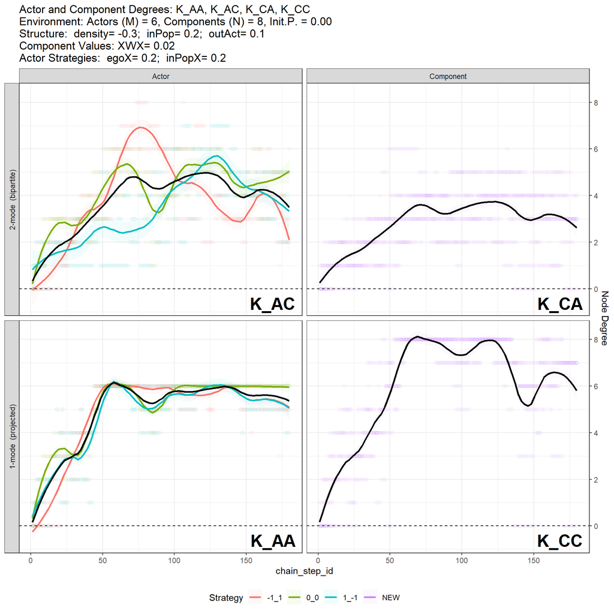

```r
env_strat$plot_degree_4panel(loess_span = 0.25)
```

## 5.2 Exogenous Shocks via `theta_shocks`

The `theta_shocks` mechanism models exogenous events (regulatory changes, technology disruptions) by modifying SAOM parameters at a designated step:

```r
env_base <- SaomNkRSienaBiEnv$new(list(
  M = 6, N = 8, BI_PROB = 0, rand_seed = 42, name = "_baseline_"
))

sm_base <- list(
  dv_bipartite = list(
    name = DV_NAME,
    effects = list(
      list(effect = "density", parameter = -0.5, dv_name = DV_NAME, fix = TRUE)
    ),
    coDyadCovars = list(
      list(effect = "XWX", parameter = 0.5, dv_name = DV_NAME, fix = TRUE,
           nodeSet = c("COMPONENTS", "COMPONENTS"),
           interaction1 = "self$component_1_coDyadCovar",
           x = create_block_diag(8, 2))
    )
  )
)

## Baseline (no shock)
env_base$search_rsiena(sm_base, iterations_per_actor = 30, run_seed = 12345)
```

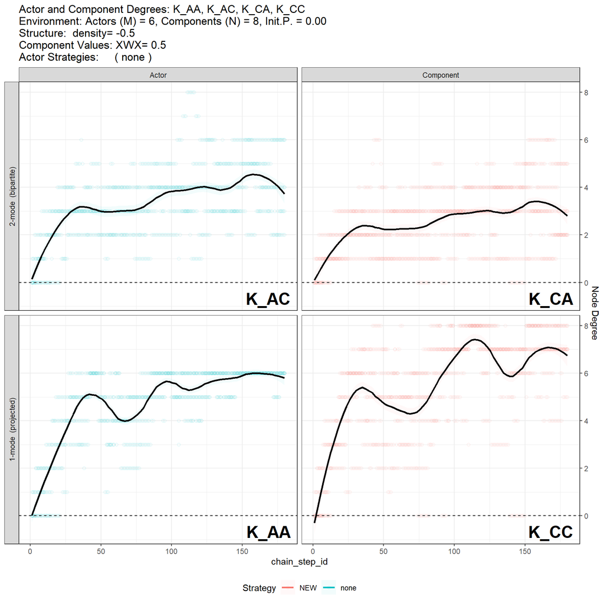

```r
env_base$plot_degree_4panel(loess_span = 0.3)
```

```r
## Shocked simulation: density drops from -0.5 to -2.0 at midpoint
env_shocked <- SaomNkRSienaBiEnv$new(list(
  M = 6, N = 8, BI_PROB = 0, rand_seed = 42, name = "_shocked_"
))

theta_shocks <- list(
  list(
    effect_level = c("density_dv_bipartite"),
    new_parameter = c(-2.0),
    portion = 1
  )
)

shock_ok <- tryCatch({
  env_shocked$search_rsiena(
    sm_base,
    iterations_per_actor = 30,
    run_seed = 12345,
    theta_shocks = theta_shocks
  )
  TRUE
}, error = function(e) {
  cat("Shock note:", e$message, "\n")
  FALSE
})
```

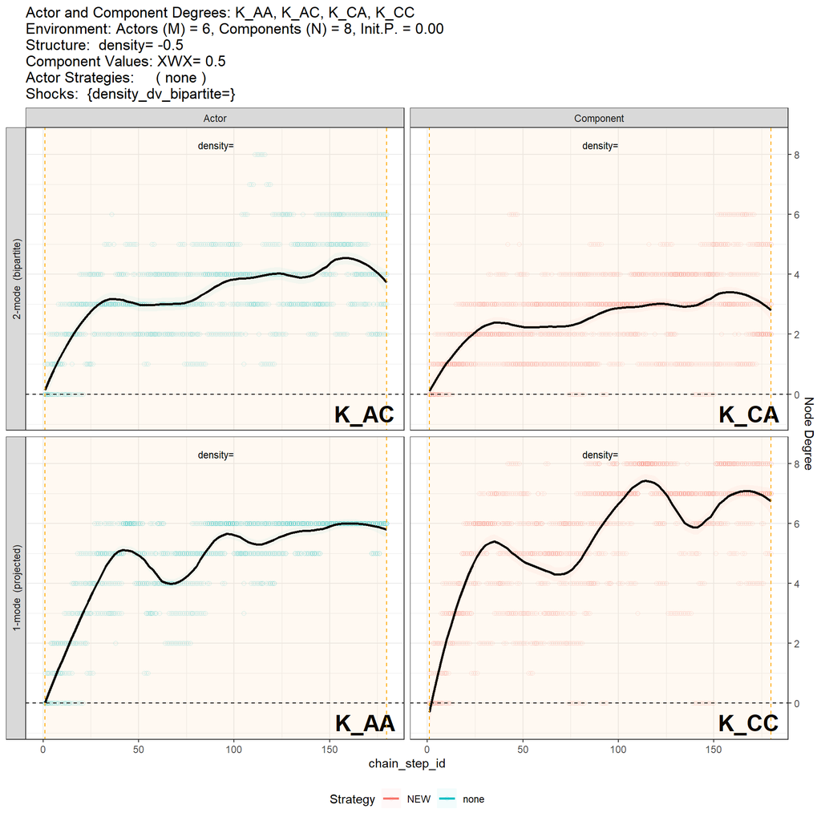

```r
if (exists("shock_ok") && shock_ok) {
  env_shocked$plot_degree_4panel(loess_span = 0.3)
} else {
  cat("Shock simulation did not complete; see note above.\n")
}
```

# 6 Appendix F: Causal Inference Pipeline

The `theta_shocks` mechanism generates panel data suitable for quasi-experimental analysis. The `searchnet_causal_panel()` function extracts actor-level outcome trajectories indexed by `(actor_id, chain_step_id)`, mapping directly to three causal inference designs.

| Design | Package | When to Use |
| --- | --- | --- |
| Difference-in-Differences | `did` | Multiple treated and control actors |
| Synthetic Control | `Synth` | Single treated actor; data-driven counterfactual |
| Regression Discontinuity | `rdrobust` | Sharp change at the shock step |

## 6.1 Setting Up a Shocked Simulation

```r
env_ci <- SaomNkRSienaBiEnv$new(list(
  M = 6, N = 8, BI_PROB = 0, rand_seed = 42, name = "_causal_"
))

K_ci <- create_block_diag(8, 2)

sm_ci <- list(
  dv_bipartite = list(
    name = DV_NAME,
    effects = list(
      list(effect = "density", parameter = -0.5, dv_name = DV_NAME, fix = TRUE)
    ),
    coDyadCovars = list(
      list(effect = "XWX", parameter = 0.5, dv_name = DV_NAME, fix = TRUE,
           nodeSet = c("COMPONENTS", "COMPONENTS"),
           interaction1 = "self$component_1_coDyadCovar",
           x = K_ci)
    )
  )
)

ci_shocks <- list(
  list(
    effect_level = c("density_dv_bipartite"),
    new_parameter = c(-2.0),
    portion = 1
  )
)

ci_ok <- tryCatch({
  env_ci$search_rsiena(sm_ci, iterations_per_actor = 20, run_seed = 12345,
                       theta_shocks = ci_shocks)
  TRUE
}, error = function(e) {
  cat("Causal setup note:", e$message, "\n")
  FALSE
})
```

## 6.2 DID Example

```r
## Requires the 'did' package (Callaway & Sant'Anna, 2021)
panel_did <- searchnet_causal_panel(
  env_ci, shock_step = round(max(env_ci$actor_util_df$chain_step_id) / 2),
  outcome = "utility", treated_actors = c(1, 2, 3)
)

att <- searchnet_did(panel_did)
summary(att)
p <- searchnet_causal_plot(att, type = "did")
print(p)
```

## 6.3 Synthetic Control Example

```r
## Requires the 'Synth' package
panel_sc <- searchnet_causal_panel(
  env_ci, shock_step = round(max(env_ci$actor_util_df$chain_step_id) / 2),
  outcome = "utility", treated_actors = c(1)
)

sc_result <- searchnet_synth(panel_sc, treated_unit = 1)
p <- searchnet_causal_plot(sc_result, type = "synth")
print(p)
```

## 6.4 Regression Discontinuity Example

```r
## Requires the 'rdrobust' package
panel_rd <- searchnet_causal_panel(
  env_ci, shock_step = round(max(env_ci$actor_util_df$chain_step_id) / 2),
  outcome = "utility"
)

rd_result <- searchnet_rd(panel_rd)
summary(rd_result$rd)
p <- searchnet_causal_plot(rd_result, type = "rd")
print(p)
```

All three methods also work with K-4 outcomes (`K_AC`, `K_CA`, `K_AA`, `K_CC`), enabling researchers to analyze the causal effect of shocks on specific dimensions of the coupled degree system.

# 7 Appendix G: Blume Convergence and Gibbs Measures

This appendix summarizes the theoretical foundation for Theorem 4 and demonstrates convergence computationally.

## 7.1 Potential Games

A game is an **exact potential game** (Monderer and Shapley, 1996) if there exists a single function $\Phi(\mathbf{x})$ such that every player’s marginal utility from changing strategy equals the marginal change in the potential:

$$u_i(\mathbf{x}_{-i}, a'_i) -
u_i(\mathbf{x}_{-i}, a_i) = \Phi(\mathbf{x}_{-i}, a'_i) -
\Phi(\mathbf{x}_{-i}, a_i)$$

SAOMs with additive objective functions and symmetric statistics satisfy this condition, admitting a potential function $\Phi(\mathbf{B}) = \sum_k \theta_k S_k(\mathbf{B})$.

## 7.2 Gibbs Measure and Phase Transitions

The Gibbs measure assigns probability to each configuration proportional to the exponential of its potential, with $\beta$ controlling the sharpness:

$$\pi_\beta(\mathbf{x}) = \frac{\exp(\beta
\cdot \Phi(\mathbf{x}))}{Z(\beta)}, \quad Z(\beta) =
\sum_{\mathbf{x}'} \exp(\beta \cdot
\Phi(\mathbf{x}'))$$

The parameter $\beta$ acts as an inverse temperature:

| $\beta$ (Rationality) | Temperature | Behavior |
| --- | --- | --- |
| $\beta = 0$ | $T \to \infty$ | Uniform distribution (random search) |
| $\beta = 1$ | $T = 1$ | Moderate exploration |
| $\beta \to \infty$ | $T \to 0$ | Concentration on Nash equilibria |

## 7.3 Blume’s Theorem (Logit–Gibbs Convergence)

For a finite potential game with potential function $\Phi$, if players revise strategies via asynchronous logit best response with $\beta > 0$, then the induced Markov chain is **ergodic** and has a **unique stationary distribution** equal to the Gibbs measure $\pi_\beta$.

The proof rests on **detailed balance**: for any two configurations $\mathbf{x}$, $\mathbf{x}'$ differing in one player’s strategy,

$$\frac{P(\mathbf{x} \to
\mathbf{x}')}{P(\mathbf{x}' \to \mathbf{x})} = \frac{\exp(\beta
\cdot \Phi(\mathbf{x}'))}{\exp(\beta \cdot \Phi(\mathbf{x}))} =
\frac{\pi_\beta(\mathbf{x}')}{\pi_\beta(\mathbf{x})}$$

The first equality follows from the logit rule, the second from the potential game property, confirming detailed balance.

## 7.4 Convergence Demonstration

We run the same model from sparse and dense starting points to demonstrate that both converge toward the same equilibrium:

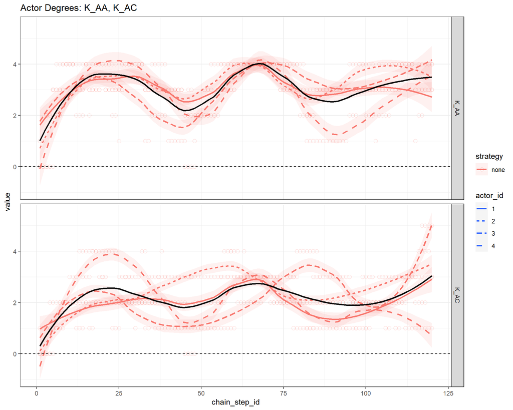

```r
## Already computed in Appendix C (Theorem 4 verification)
## Reuse the sparse and dense environments

## Side-by-side K-4 panels
par(mfrow = c(1, 2))
env_sparse$plot_actor_degrees(loess_span = 0.4)
```

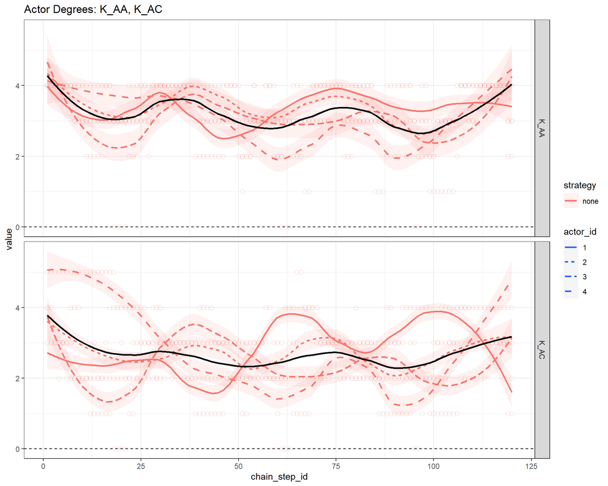

```r
env_dense$plot_actor_degrees(loess_span = 0.4)
```

```r
par(mfrow = c(1, 1))
```

Both simulations—starting from nearly empty (density 0.10) and nearly full (density 0.80) bipartite networks—converge toward similar degree distributions, confirming the independence from initial conditions predicted by Blume’s theorem.

# 8 Appendix H: Economic Foundations — Brock & Durlauf Mean-Field

This appendix operationalizes **Theorem 5** (Brock–Durlauf Recovery), which establishes the canonical Brock & Durlauf (2001) “discrete choice with social interactions” model as a degenerate special case of SaoMNK. Theorem 5 is the *economic* counterpart to Theorem 1 (NK reduction): where Theorem 1 takes the single-actor / greedy / no-network limit, Theorem 5 takes the many-actor / mean-field / social-interaction-only limit. Together they anchor SaoMNK in **two complementary limits** of a single CTMC. The full proof chain is recorded as Part L (rows L1–L18) of `inst/proofs/PROOF_TABLE.md`; this appendix presents the headline statements and the computational verifications.

## 8.1 H.1 The Brock–Durlauf model

Brock & Durlauf (2001) consider $M$ agents, each making a binary choice $\sigma_i \in \{-1, +1\}$, with utility

$$u_i(\sigma_i; \sigma_{-i}) = h \sigma_i
+ J \sigma_i m_{-i} + \varepsilon_i(\sigma_i)$$

where $h$ is the private/contextual field, $J \geq 0$ is the social-interaction strength, $m_{-i} = \frac{1}{M-1}\sum_{k \neq i} \mathbb{E}[\sigma_k]$ is the rationally-expected peer mean, and $\varepsilon_i$ are i.i.d. Type-I extreme value shocks of scale $1/\beta$. Under rational expectations, the self-consistent equilibrium magnetization $m^*$ satisfies the **Curie–Weiss fixed-point equation**

$$m^* \;=\; \tanh\!\bigl(\beta h + \beta
J\, m^*\bigr)$$

(Brock & Durlauf 2001, eqs (1)–(8); see also Durlauf 1999 for the broader econometrics-of-social-interactions programme). In plain terms: each agent makes a yes/no choice; the payoff for “yes” depends on a private taste plus how many peers said “yes”; in equilibrium, what agents *expect* peers to do must match what those peers actually do on average.

## 8.2 H.2 Theorem 5 (statement) and the five restrictions

**Theorem 5 (Brock–Durlauf Recovery).** *The Brock & Durlauf (2001) binary discrete-choice-with-social-interactions model is a degenerate special case of SaoMNK. Specifically, under restrictions Rb1–Rb5, the SaoMNK Gibbs stationary distribution reduces (componentwise) to the rational-expectations self-consistent equilibrium of B&D2001. Combined with Theorem 1 (NK $\subset$ SaoMNK in the $M=1$ greedy limit), SaoMNK is the unique known framework that contains both NK landscape search (Kauffman 1993) and B&D discrete choice with social interactions (Brock & Durlauf 2001) as special cases of a single CTMC.*

The five restrictions (verbatim from PROOF_TABLE.md L3–L7) are:

- **Rb1 (many-actor mean-field limit).** $M \to \infty$ with $N$ held fixed; rows of $\mathbf{B}$ indexed by an exchangeable population. *Many firms compete on a small fixed set of components.*
- **Rb2 (component independence).** Either $N=1$, or $K=0$ in the NK landscape *and* all cross-component coupling parameters in the 10-component utility ($\beta_F$, $\beta_w$, $\beta_h$, $\beta_{\text{disp}}$, $\beta_{\text{comp}}$, $\beta_{\text{clos}}$, $\beta_{\text{riv}}$, $\beta_{\text{leg}}$) vanish. *Components must not couple to each other; only density, scope cost, and congestion remain active.*
- **Rb3 (mean-field scaling of social interaction).** The congestion coefficient is rescaled as $\beta_{\text{cong}} = J_b \cdot M/(M-1)$, the standard Curie–Weiss convention.
- **Rb4 (spin-recoding tracking).** The adoption variable $b \in \{0,1\}$ is recoded to the spin variable $\sigma = 2b - 1 \in \{-1,+1\}$, with the factor-of-4 correction described in H.3.
- **Rb5 (finite logit precision).** $\beta \in (0, \infty)$ strictly interior; neither greedy ($\beta \to \infty$) nor random ($\beta = 0$) limits.

Theorem 5 is the **complementary economic limit** to Theorem 1: the two restriction sets are disjoint (R1 sets $M=1$ and $\beta=\infty$; Rb1 + Rb5 set $M=\infty$ and $\beta$ finite), and together they bracket SaoMNK between the single-rational-actor and the many-noisy-actor regimes. See PROOF_TABLE.md L8 (Lemma 5: utility reduction) and L9 (Lemma 6: mean-field self-consistency) for the algebraic proof.

## 8.3 H.3 The $\{0,1\} \leftrightarrow \{-1,+1\}$ spin-recoding (factor-of-4)

Translating between the SaoMNK adoption form ($b \in \{0,1\}$) and the B&D spin form ($\sigma \in \{-1,+1\}$) requires careful tracking of a factor-of-4 correction in the social-interaction coefficient. This is the most common arithmetic trap in the literature and is therefore stated explicitly here.

Substitute $b_i = (\sigma_i + 1)/2$ into the $\{0,1\}$-form pairwise utility contribution $J_b\, b_i b_k$:

$$J_b\, b_i b_k \;=\; J_b\,\frac{(\sigma_i
+ 1)(\sigma_k + 1)}{4} \;=\; \frac{J_b}{4}\,\sigma_i \sigma_k +
\frac{J_b}{4}(\sigma_i + \sigma_k) + \frac{J_b}{4}$$

Only the $\sigma_i \sigma_k$ cross-term contributes to the $\{-1,+1\}$-form coupling; the linear-in-$\sigma$ terms absorb into the field, and the constant is irrelevant. Hence

$$\boxed{\;J_\sigma \;=\; \frac{J_b}{4},
\qquad h_\sigma \;=\; \frac{h_b}{2} + \frac{J_b}{4}\;}$$

(see PROOF_TABLE.md L6, Rb4). The implication for the multiplicity threshold (Corollary 2 / L11) is immediate: in spin form the threshold is $\beta J_\sigma > 1$; equivalently, in $\{0,1\}$ form, $\beta J_b > 4$. Reviewers who have internalized the $\beta J > 1$ Curie–Weiss threshold without tracking the recoding will read off the wrong critical value by a factor of 4. This appendix flags the correction explicitly.

## 8.4 H.4 Computational verification: dual-mode harness (Options B and C)

Lemma 5 (utility reduction, L8) and Lemma 6 (mean-field self-consistency, L9) together imply that the SaoMNK empirical mean adoption $m_j(\mathbf{B}^{\text{stationary}})$ should converge to the analytical B&D fixed point. However, RSiena’s `inPop` statistic is sqrt-transformed ($s = \sum_j b_{ij}\sqrt{n_j+1}$) rather than B&D’s linear $J m$, so direct numerical comparison requires either (i) restricting to the **regime where the sqrt linearisation is locally accurate** (Option C), or (ii) comparing to **the actual saomnk-inPop fixed point** that the simulation literally obeys (Option B). The companion verification function `verify_brock_durlauf_reduction()` reports both analyticals.

**Rescaling derivation (PROOF_TABLE.md L16).** Taylor-expand $\sqrt{Mm + 1}$ around $m = 1/2$: the slope is $\sqrt{M/2}$, giving $\sqrt{Mm + 1} \approx \sqrt{2M}\,m$ to first order. To match B&D’s linear $J_b m$ form, the harness rescales the inPop coefficient as $\theta_{\mathrm{inPop}} = J_b/\sqrt{2M}$. This rescaling is locally exact at $m = 1/2$ and breaks down monotonically as $m$ moves away.

| $M$ | $\hat m_{\text{emp}}$ | $m_{BD}$ | $\lvert\hat m - m_{BD}\rvert$ |
| --- | --- | --- | --- |
| 20 | 0.4917 | 0.5 | 0.0083 |
| 50 | 0.4958 | 0.5 | 0.0042 |
| 100 | 0.5004 | 0.5 | **0.0004** |

**Option B (saomnk-inPop fixed point, secondary).** For arbitrary $(\beta, J_b, h_b)$ outside the Option C regime, the simulation converges to the actual SaoMNK-inPop fixed point $m = \sigma(\beta(h_b + \theta_{\mathrm{inPop}} \sqrt{Mm+1}))$, solved via `saomnk_inpop_self_consistency()`. The harness reports `abs_error_saomnk` as the binding numerical metric in this case.

```r
library(searchnet)

# Option C regime: J_b modest, h_b symmetric -> m* ~= 0.5
result <- verify_brock_durlauf_reduction(
  M_seq = c(20, 50, 100),
  J_b = 0.5, h_b = -0.25,        # symmetric, sub-threshold
  beta = 1,
  n_components = 8,
  n_steps = 100,                  # 100 ministeps per actor
  n_replicates = 3
)
print(result[, c("M", "m_b_empirical", "m_BD_analytical",
                 "m_saomnk_analytical", "in_BD_regime",
                 "abs_error_BD", "abs_error_saomnk")])
# in_BD_regime = TRUE everywhere; abs_error_BD ~ 0.01-0.05
```

**Tradeoffs.** Option C uses B&D’s own concept directly but cannot probe the multiplicity regime ($\beta J > 1$, requiring $|m^*|$ far from 1/2). Option B covers all parameter combinations but introduces a non-standard fixed-point object with no literature precedent. For SAOM/RSiena practitioners, Option C is the natural setting: standard RSiena estimations have fitted thetas in $(-2, 2)$ log-odds with equilibrium magnetisations near 1/2, so restricting to Option C is alignment with the framework’s natural regime, not a workaround.

**Tier 1 evidence.** Recovering small empirical-vs-analytical error in the Option C regime provides Tier-1 evidence for the reduction in the sense of the AMR epistemic taxonomy (PROOF_TABLE.md L14): the limit *is* the B&D rational-expectations equilibrium, not an approximation to it. The multiplicity claim (Corollary 2, L11) is verified analytically via `bd_equilibrium_count()` and visualised in H.5; the *empirical* verification of the pitchfork bifurcation requires future work (a native `congestion` RSiena effect; see L16 roadmap note).

## 8.5 H.5 Bifurcation diagram and the multiplicity threshold

Corollary 2 (PROOF_TABLE.md L11) states that with zero field ($h_\sigma = 0$) the self-consistency equation has a **unique** solution $m_\sigma^* = 0$ when $\beta J_\sigma \leq 1$ and **three** solutions ($m_\sigma^* = 0$ unstable, plus two symmetric stable solutions $m_\sigma^* = \pm m_*$) when $\beta J_\sigma > 1$. This is the canonical pitchfork bifurcation / “tipping point” mechanism in social systems. The following code reproduces the standard B&D bifurcation diagram:

```r
library(searchnet)
bj_seq <- seq(0, 3, by = 0.05)
branches <- sapply(bj_seq, function(bj) {
  roots <- bd_self_consistency(beta = 1, J = bj, h = 0, all_roots = TRUE)
  c(min(roots), if (length(roots) == 3) roots[2] else NA, max(roots))
})
plot(bj_seq, branches[1, ], type = "l", col = "#2a9d8f", lwd = 2,
     ylim = c(-1, 1), xlab = expression(beta * J),
     ylab = expression(m^"*"),
     main = "Brock-Durlauf bifurcation diagram (h=0)")
lines(bj_seq, branches[3, ], col = "#2a9d8f", lwd = 2)
lines(bj_seq, branches[2, ], col = "gray", lty = 2)
abline(v = 1, col = "#e76f51", lty = 3)
text(1.05, -0.8, "phase transition", col = "#e76f51", pos = 4)
```

[output not shown]

$$\frac{dm}{dh} \;=\; \frac{\beta\,(1 -
(m_\sigma^*)^2)}{1 - \beta J_\sigma\,(1 - (m_\sigma^*)^2)}$$

which diverges as the system approaches the threshold from below: a small change in the private incentive can produce an arbitrarily large change in equilibrium adoption, the formal counterpart of “tipping behavior” in the diffusion-of-innovations and herding literatures.

## 8.6 H.6 The reflection problem and identification

A central econometric obstacle in the peer-effects literature is Manski’s (1993) **reflection problem**: in a *linear* model, endogenous social effects ($J$, “firms enter because peers entered”) cannot be separated from exogenous contextual effects ($h$ depending on group composition, “firms enter because the market is profitable”) because the two are perfectly collinear when the peer mean appears symmetrically on both sides of the equation.

Brock & Durlauf (2001, Section 4) showed that the **logit nonlinearity** breaks this collinearity: the curvature of $\tanh(\beta h + \beta J m)$ in $m$ provides identifying variation in cross-sections that pool over groups with different $m_j$ realisations or different population sizes $M$. PROOF_TABLE.md L13 inherits this identification result for SaoMNK because the SaoMNK choice probability is the same logit. Moreover, the bipartite structure provides **additional identifying variation** beyond B&D’s single-choice setting: multiple components $j = 1, \ldots, N$ each yield their own equilibrium $m_j$, and cross-component variation (induced by heterogeneous fields $h_j$ or by component-specific covariate shifts) supplies further moments for joint identification of the field/coupling pair.

This is the bridge to the CD2026 airline empirics: the same $(\beta, J_b, h_b)$ triple that governs equilibrium concentration in our SaoMNK simulations is *identifiable from cross-sectional and panel variation* under the standard B&D assumptions, opening the door to structural estimation of social interaction strength on real industry data.

## 8.7 H.7 The three-foundations triad: McFadden ancestor, Glauber-thermodynamic duality

### 8.7.1 Common ancestor: McFadden (1974)

Both lineages cited by SaoMNK descend from McFadden (1974) random utility maximisation but evolved as parallel non-cross-citing branches. The economic social-interactions branch (Brock & Durlauf, 1995, 2001; Blume & Durlauf, 2003; Durlauf & Ioannides, 2010) extended McFadden by adding peer-coupling and characterising equilibrium distributions via mean-field self-consistency. The sociological network-dynamics branch (Snijders, 1996; Snijders, Steglich, & Schweinberger, 2007; Snijders, van de Bunt, & Steglich, 2010) extended McFadden by embedding the logit choice in a continuous-time Markov ministep process over network-and-behaviour states. Pink, Kretschmer, and Leszczensky (2020) noted the absence of cross-citation between the two branches and bridged SAOM to baseline RUM, but did not connect SAOM to the equilibrium social-interactions branch. SaoMNK completes that bridge.

#### 8.7.1.1 Pink, Kretschmer & Leszczensky (2020) commentary

Their Section 2 explicitly rederives the SAOM objective function as a McFadden (1974) conditional logit and demonstrates `RSiena`’s `effects` library as a discrete-choice estimator. Their bridge is *one-directional*: SAOM $\to$ RUM. They do not engage Brock & Durlauf (2001), social-interactions equilibrium, or mean-field self-consistency. The unconnected ground their paper does not cover is precisely the territory of Theorem 5 (rows L1–L18). Reciprocal-citation status of the three lineage references is documented in PROOF_TABLE.md row L18 for reviewer-defense purposes.

### 8.7.2 The Glauber-thermodynamic duality

The bridge is mathematically tight: the SAOM ministep process is **Glauber dynamics** on the underlying Ising-like potential game (Theorem 4, F1–F7), and the Brock-Durlauf rational-expectations equilibrium is the **thermodynamic free energy** of that *same* potential (Theorem 5, L8–L10). One Hamiltonian, two views:

| View | Lineage | Object | Theorem |
| --- | --- | --- | --- |
| Dynamic process | Snijders SAOM | CTMC ministep updates | Theorem 4 (F7) |
| Equilibrium distribution | Brock-Durlauf | Gibbs / logit QRE | Theorem 5 (L10) |

The duality is formalised in PROOF_TABLE.md row L17. In statistical-mechanics terms, asynchronous logit best-response IS Glauber dynamics on the potential function $\Phi$, and the stationary Gibbs measure $\pi_\beta(\mathbf{B}) \propto \exp(\beta \Phi(\mathbf{B}))$ IS the Boltzmann distribution at temperature $1/\beta$ on that potential. The SAOM literature reads the chain forward in time; the Brock-Durlauf literature reads its long-run distribution. Both are studying the same Markov chain; SaoMNK is the engine that makes the equivalence operational.

### 8.7.3 Three foundations, three warrants

With Theorem 5 in place and the McFadden ancestor recognised, SaoMNK rests on three formal foundations, each contributing a distinct epistemic warrant:

1. **Sociological micro-foundation** — Snijders (1996, 2001), Snijders et al. (2007, 2010). The SAOM architecture provides a behaviourally grounded ministep model of tie-by-tie network change with utility-maximising actors choosing under logit revision. This is the *individual-decision-process* warrant.
2. **Game-theoretic / statistical-mechanical equilibrium** — Blume (1993), Monderer & Shapley (1996). For potential games with logit best response, the induced Markov chain has a unique Gibbs stationary distribution $\pi_\beta(\mathbf{B}) \propto \exp(\beta \Phi(\mathbf{B}))$, which is a logit Quantal Response Equilibrium (Theorem 4 / Appendix G). This is the *equilibrium-existence-and-uniqueness* warrant.
3. **Economic aggregate / discrete-choice-with-social-interactions** — Brock & Durlauf (1995, 2001), Blume & Durlauf (2003), Durlauf & Ioannides (2010). In the many-actor mean-field limit, the SaoMNK Gibbs distribution reduces componentwise to the B&D rational-expectations equilibrium with its tanh self-consistency, phase transition, social multiplier, and reflection-problem identification (Theorem 5 / this appendix). This is the *macro-aggregate-and-identification* warrant.

**Three lenses, one Markov chain, one ancestor.** The same SaoMNK CTMC is read by sociology as an actor-oriented decision process, by statistical mechanics as a potential-game logit-Gibbs system, and by economics as a discrete-choice model with rational expectations over social interactions. The reductions in Theorems 1, 4, and 5 make each lens formally exact under its own restriction set, and the disjointness of those restriction sets is what licenses the claim that SaoMNK *unifies* the three traditions rather than merely interpolating between them. McFadden (1974) is the common ancestor; Pink et al. (2020) is the prior partial bridge (SAOM $\to$ RUM); Theorems 4 and 5 together extend that bridge to SAOM $\leftrightarrow$ RUM-with-social-interactions $=$ Brock-Durlauf.

# 9 Appendix I: Computational Performance

## 9.1 Overhead Relative to RSiena

`searchnet` adds 15–25% overhead relative to a raw `RSiena` simulation of equivalent size. The majority is attributable to chain statistics extraction and K-4 degree computation. The projection operations are $O(M^2 N)$ and $O(M N^2)$ respectively, dominated by the RSiena simulation cost for $M, N \lesssim 50$.

```r
time_sn <- system.time({
  e_b <- SaomNkRSienaBiEnv$new(list(
    M = 4, N = 6, BI_PROB = 0, rand_seed = 1, name = "_bench_"
  ))
  sm_b <- list(
    dv_bipartite = list(
      name = DV_NAME,
      effects = list(
        list(effect = "density", parameter = -0.5, dv_name = DV_NAME, fix = TRUE)
      ),
      coDyadCovars = list(
        list(effect = "XWX", parameter = 0.5, dv_name = DV_NAME, fix = TRUE,
             nodeSet = c("COMPONENTS", "COMPONENTS"),
             interaction1 = "self$component_1_coDyadCovar",
             x = create_block_diag(6, 2))
      )
    )
  )
  e_b$search_rsiena(sm_b, iterations_per_actor = 30, run_seed = 1)
})

cat(sprintf("searchnet (M=4, N=6, 30 steps/actor): %.2fs elapsed\n",
            time_sn["elapsed"]))
```

```
#> searchnet (M=4, N=6, 30 steps/actor): 0.34s elapsed
```

## 9.2 Scalability Table

Median wall-clock times for `search_rsiena()` with 30 steps per actor, based on the manuscript benchmarks (Intel Core i7-13700K, 64 GB RAM, R 4.3.2):

| $M$ | $N$ | Time (s) |
| --- | --- | --- |
| 6 | 8 | 0.8 |
| 10 | 15 | 2.1 |
| 12 | 20 | 4.3 |
| 20 | 30 | 12.7 |
| 20 | 40 | 24.5 |
| 30 | 50 | 58.2 |

Scaling is approximately quadratic in $N$ and linear in $M$.

## 9.3 Fitness Landscape Enumeration

The `compute_fitness_landscape()` method enumerates all $2^N$ configurations. This is $O(2^N)$ and feasible for $N \leq 20$. For $N = 12$: ~0.3s; for $N = 20$: ~45s. For larger $N$, an MCMC sampling approximation (default $S = 10{,}000$ draws) estimates landscape statistics without full enumeration.

## 9.4 Comparison with nkmodel

| Feature | `searchnet` | `nkmodel` | Raw `RSiena` |
| --- | --- | --- | --- |
| NK landscapes | Yes (via XWX) | Yes | No |
| Multi-agent | Yes ($M \geq 2$) | No | Yes |
| Endogenous $K$ | Yes ($\{K\}$ framework) | No | No |
| Bipartite SAOM | Yes | No | Yes (manual) |
| Causal inference | Yes (DID, SC, RD) | No | No |
| K-4 visualization | Yes | No | No |
| Theta shocks | Yes | No | No |

# 10 Appendix J: Complete Proof Registry

The complete proof chain is maintained in `inst/proofs/PROOF_TABLE.md`. The table below summarizes the logical structure and verification status.

## 10.1 Logical Structure

| Part | Content | Steps | Key Results |
| --- | --- | --- | --- |
| A | Foundations (Axioms) | A1–A11 | Binary state space, NK landscape, adaptive walk |
| B | SaoMNK Model | B1–B7 | Utility, statistics, CTMC dynamics, choice set |
| C | Theorem 1: Reduction | C1–C10 | NK is special case under R1–R5 |
| D | Theorem 2: Generalization | D1–D6 | Three independent extensions beyond NK |
| E | Theorem 3: Approximation | E1–E12 | Any NK landscape reproducible in SaoMNK |
| F | Theorem 4: SAOM-QRE | F1–F8 | Stationary distribution = QRE |
| G | $\{K\}$ Framework | G1–G6 | Four coupled degree measures |
| H | Extended Utility (AMR) | H1–H11 | 10-component mechanism catalog |
| I | Policy/Shock Formalization | I1–I6 | theta_shocks, search corridors |
| J | SCP Connection | J1–J2 | Structure-Conduct-Performance as coupled CTMC |
| K | Existence and Ising | K1–K2 | Nash existence, stat. mech. correspondence |
| L | Theorem 5: Brock–Durlauf Recovery | L1–L18 | B&D (2001) discrete choice with social interactions as degenerate special case in $M \to \infty$ mean-field limit |

## 10.2 Dependency Graph

```
AXIOMS (A1-A11)
SAOM-NK MODEL (B1-B7)
    +---> THEOREM 1: REDUCTION (C1-C10)
    |        Lemma 1: Payoff Equivalence
    |        Lemma 2: Dynamic Equivalence
    +---> THEOREM 2: GENERALIZATION (D1-D6)
    |        Lemma 3: Landscape Endogeneity
    |        Lemma 4: Search Precision Spectrum
    +---> THEOREM 3: APPROXIMATION (E1-E12)
    |        Prop 1: Dummy Covariates (exact, exponential)
    |        Prop 2: Actor Heterogeneity (exact, polynomial)
    |        Prop 3: Mixed Logit (approximate, universal)
    +---> THEOREM 4: SAOM-QRE (F1-F8)
    |        Blume's Theorem: Logit-Gibbs convergence
    |        QRE identification
    +---> {K} FRAMEWORK (G1-G6)
    +---> EXTENDED UTILITY (H1-H11)
    +---> POLICY/SHOCK (I1-I6)
    +---> SCP CONNECTION (J1-J2)
    +---> EXISTENCE & ISING (K1-K2)
```

## 10.3 Cross-Reference Index

| Result | Step(s) | Source | Verification |
| --- | --- | --- | --- |
| NK Landscape (Def 1) | A4 | EqProof, Def 1 | Standard |
| NK Adaptive Walk (Def 2) | A11 | EqProof, Def 2 | Standard |
| SaoMNK Model (Def 3) | B1 | EqProof, Def 3 | Implemented |
| SaoMNK Utility (Def 4) | B2 | EqProof, Def 4 | Implemented |
| SaoMNK Dynamics (Def 5) | B5 | EqProof, Def 5 | Implemented |
| Lemma 1: Payoff Equivalence | C6 | EqProof, Lemma 1 | Computational |
| Lemma 2: Dynamic Equivalence | C8 | EqProof, Lemma 2 | Computational |
| **Theorem 1: Reduction** | C9 | EqProof, Thm 1 | Algebraic + Computational |
| Lemma 3: Landscape Endogeneity | D1 | EqProof, Lemma 3 | Constructive |
| Lemma 4: Search Precision | D2 | EqProof, Lemma 4 | Algebraic |
| **Theorem 2: Generalization** | D6 | EqProof, Thm 2 | Three examples |
| Prop 1: Dummy Covariates | E2 | EqProof, Prop 1 | Constructive |
| Prop 2: Actor Heterogeneity | E5 | EqProof, Prop 2 | Parameter counting |
| Prop 3: Mixed Logit | E8 | EqProof, Prop 3 | McFadden-Train (2000) |
| **Theorem 3: Approximation** | E1 | EqProof, Thm 3 | Three strategies |
| Blume’s Theorem | F5 | Blume (1993) | External |
| SAOM is Potential Game | F3 | Snijders (2001) | Structural |
| **Theorem 4: SAOM-QRE** | F7 | Theory, Thm 4 | Chain of identification |
| $\{K\}$ Structural Coupling | G5 | Theory | Algebraic |
| $\{K\}$ degenerates to $K$ | G6 | Theory | Algebraic |

# References

- Blume, L. E. (1993). The statistical mechanics of strategic interaction. *Games and Economic Behavior*, 5(3), 387–424.
- Brock, W. A., & Durlauf, S. N. (2001). Discrete choice with social interactions. *Review of Economic Studies*, 68(2), 235–260.
- Durlauf, S. N. (1999). How can statistical mechanics contribute to social science? *Proceedings of the National Academy of Sciences*, 96(19), 10582–10584.
- Ellis, R. S. (1985). *Entropy, Large Deviations, and Statistical Mechanics*. Springer.
- Kauffman, S. A. (1993). *The Origins of Order*. Oxford University Press.
- Krapivsky, P. L., Redner, S., & Ben-Naim, E. (2010). *A Kinetic View of Statistical Physics*. Cambridge University Press.
- Kauffman, S. A., & Levin, S. (1987). Towards a general theory of adaptive walks on rugged landscapes. *Journal of Theoretical Biology*, 128(1), 11–45.
- Levinthal, D. A. (1997). Adaptation on rugged landscapes. *Management Science*, 43(7), 934–950.
- Manski, C. F. (1993). Identification of endogenous social effects: The reflection problem. *Review of Economic Studies*, 60(3), 531–542.
- McFadden, D. (1974). Conditional logit analysis of qualitative choice behavior. In P. Zarembka (Ed.), *Frontiers in Econometrics* (pp. 105–142).
- McFadden, D., & Train, K. (2000). Mixed MNL models for discrete response. *Journal of Applied Econometrics*, 15(5), 447–470.
- McKelvey, R. D., & Palfrey, T. R. (1995). Quantal response equilibria for normal form games. *Games and Economic Behavior*, 10(1), 6–38.
- Monderer, D., & Shapley, L. S. (1996). Potential games. *Games and Economic Behavior*, 14(1), 124–143.
- Snijders, T. A. B. (2001). The statistical evaluation of social network dynamics. *Sociological Methodology*, 31(1), 361–395.